# SHAP Foundations

Author

Kris Sankaran

Published

February 23, 2026

*Readings: [1](https://arxiv.org/abs/2207.07605) (required), [2](https://proceedings.mlr.press/v108/janzing20a.html) (optional)*, *[Code](https://github.com/krisrs1128/stat479_notes/blob/master/notes/09-shap_definitions.qmd)*

Bullet items with $^{\dagger}$ are not in the required reading, so not tested.

## Setup

**Goal.** Given a model $f$ and a sample $x \in \reals^{D}$, return a *local feature attribution* $\varphi_d\left(x\right)$ that quantifies the contribution of feature $d$ to the prediction $f\left(x\right)$.

**Requirements.**

- *Local feature attributions*. Unlike global variable importances, $\varphi_d\left(x\right)$ are specific to sample $x$. This matters a stakeholder cares specifically about particular prediction $f(x)$ and wants an explanation for it.
- *Model agnostic*. Attributions should be computable by querying $f$ alone, without any assumptions about what kind of model it is – it could be a black box.
- *Principled.* The attribution measure should be derivable from a clear set of mathematical axioms.

**Approach.**

SHAP values satisfy all three requirements. This handout focuses on their theoretical development. Practical computation comes next week. We proceed in these steps,

1. *Game theory definitions.* SHAP is inspired by a classic result $n$-player game theory. We’re not interested in game theory for its own sake, but this framing will help us see why there are several defensible ways to adapt it to machine learning.
2. *Machine learning analogy.* We develop an analogy between the game theoretic definition and quantities of interest in local feature attribution.
3. *Feature removal.* The most ambiguous part of the game theory $\to$ ML analogy is how implement “feature removal.” Different choices lead to different SHAP variants

## Local Feature Attributions

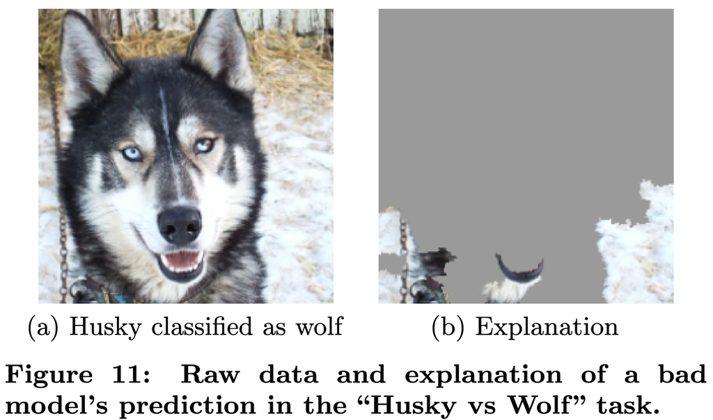

   *Exercise: Give one example (hypothetical, or from your own experience) where local feature attribution would be useful. How would it differ from global variable importance?*

## Game Theory Definitions

1. SHAP is motivated by the credit assignment problem from game theory. Imagine agents $\mathcal{D} = \{1, \dots, D\}$ where any subset $S$ earns profit $v(S)$. How much of the total profit $v(\mathcal{D})$ should agent $d$ receive? This share is the **Shapley value** $\varphi_{d}(v)$.
2. Intuitively, agent $d$’s contribution depends on how much they add to each team $S$. Define the marginal contributions of agent $d$ to team $S$ as,
   $$C\left(d \vert S\right) = v(S \cup \{d\}) - v(S)$$

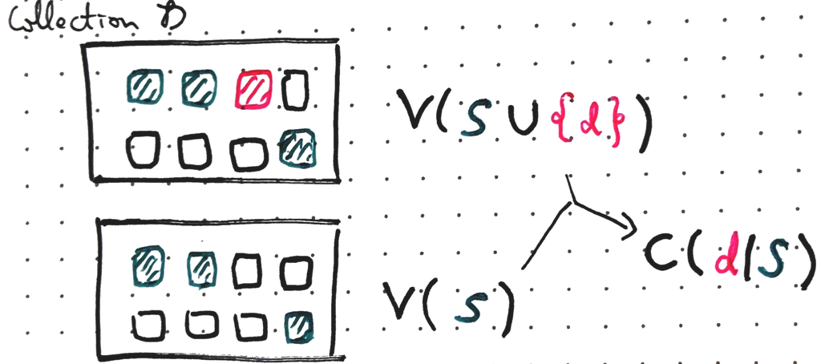

3. The Shapley value is a weighted average of these marginal contributions across all subsets $S \subseteq{\mathcal{D} - \{d\}}$ excluding agent $d$,

   $$\varphi_d(v) = \sum_{S \subseteq \mathcal{D} - \{d\}} \frac{1}{D {D - 1 \choose \left|S\right|}} C(d \vert S)
   \tag{1}$$
   The summation is over all subsets that don’t include agent $\{d\}$ (if it had included agent $d$, then the definition of the contribution $C(d \vert S)$ of $d$ to $S$ wouldn’t make sense).

   *Exercise: Express the following in terms of $v$. Which of these could appear in the definition of the Shapley value?*
   - *$C(1 \vert 2)$*
   - *$C(1 \vert \emptyset)$*
   - *$C(1 \vert 1)$*
   - *$C(3 \vert \{1, 2\})$*
   - *$C(\{1, 2\} \vert 3)$*
4. The weights $1/(D {D - 1 \choose \left|S\right|})$ ensure that the weights sum to 1, making $\varphi_{d}(v)$ a proper weighted average of marginal contributions. For any coalition of size $s$, there are ${D - 1 \choose s}$ subsets with that size, so the total weight is,

   $$\sum_{s=0}^{D-1} \binom{D-1}{s} \frac{1}{D\binom{D-1}{s}} = \sum_{s=0}^{D-1} \frac{1}{D} = 1.$$

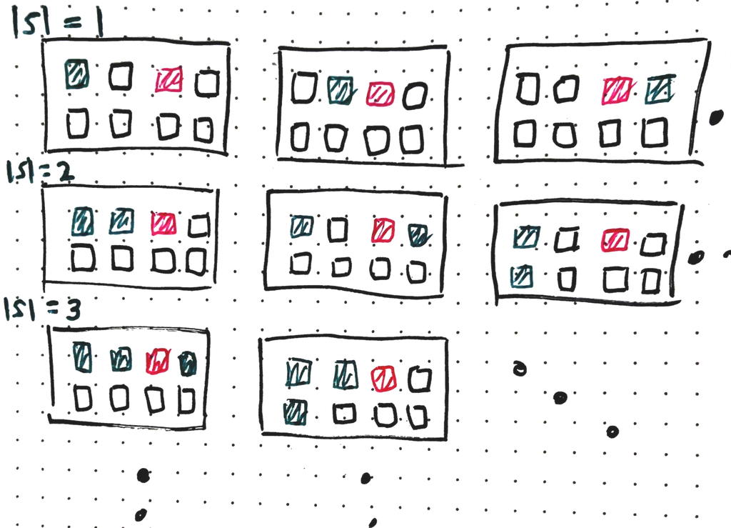

5. The Shapley value is the unique solution satisfying the axioms below, giving this approach a principled justification,
   - **Efficiency**. Shapley values sum to the total profit:
     $$\sum_{d = 1}^{D} \varphi_{d}(v) = v\left(\mathcal{D}\right) - v\left(\emptyset\right)$$
     All profit is distributed and nothing is left over.
   - **Monotonicity**. If agent $d$ contributes at least as much in game $v_1$ as in $v_2$ for every coalition[^1], then $\varphi_d(v_1) \geq \varphi_d(v_2)$.
   - **Symmetry**. Equal contributors receive equal credit. That is, if $v(S \cup \{d\}) = v(S \cup \{d'\})$ for every $S$, then $\varphi_d(v) = \varphi_{d'}(v)$.
   - **Missingness**. An agent that never contributes receives nothing. That is, if $v\left(S \cup \{d\}\right) = v\left(S\right)$ for every $S$, then $\varphi_d(v) = 0$.

## Machine Learning Analogy

1. The key insight is that we can map this game theoretic setup to the local feature attribution problem:
   - “profit $v(\mathcal{D})$” $\to$ “prediction $f(x)$”
   - “agent $d$” $\to$ “feature $d$.”
   - “team $S$” $\to$ “subset of features $S \subset \mathcal{D}$.”

   Instead of distributing profit across agents, we attribute a prediction $f(x)$ across features. We denote this attribution $\varphi_d(f, x)$

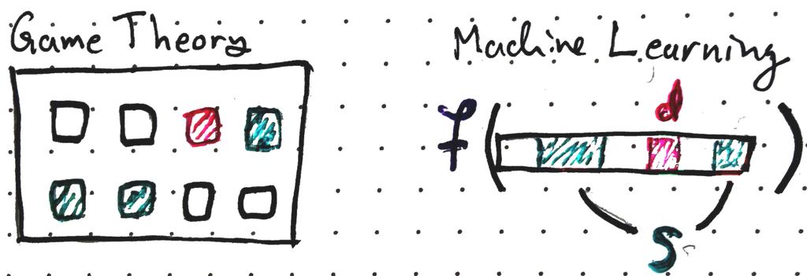

2. For this to work, we need to define $C(d \vert S)$ as the change in prediction feature $d$ is included vs. removed. Different answers to this feature removal question lead to different Shap values. But once $C$ is defined, we can substitute it into Equation 1 to get a local feature attribution for sample $x$.

   *Exercise: Pick one of the four axioms for game theoretic SHAP. What does it imply about $\varphi_d(f, x)$?*

## Deterministic Feature Removal

1. There are three common approaches to feature removal: baseline, marginal, and conditional. We’ll review each in turn.
2. Let $x'$ denote a *baseline* value. For example, $\mathbf{0}\in \reals^{D}$, or the sample mean $\bar{x} \in \reals^{D}$. Define
   $$v(S) = f(x_{S}, x'_{\bar{S}}) \\$$
   where $x_{S}$ and $x_{\bar{S}}$ index the coordinates of $x$ included and excluded from $S$. This uses the real feature values from sample $x$ for coordinates in $S$ and substitutes the baseline $x'$ elsewhere.

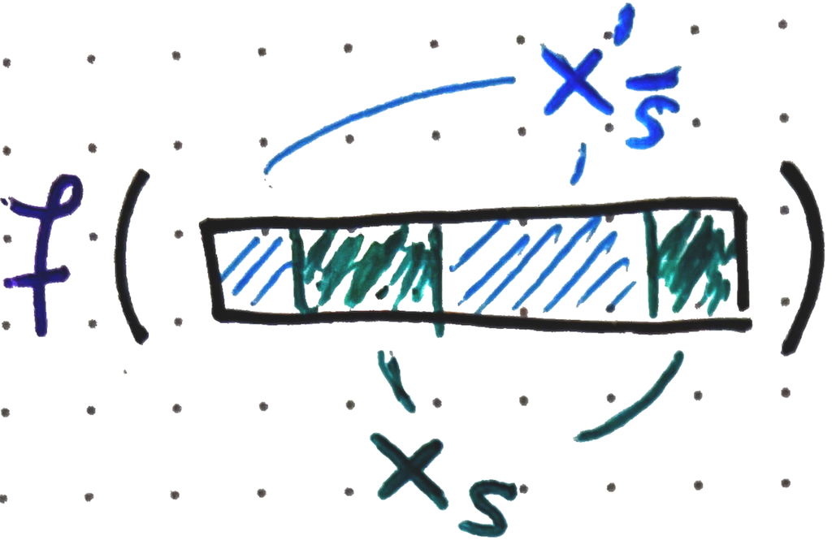

   *Exercise: Suppose that $x$ is an image and that $x'$ is the all zeros image. What would $\left(x_{S}, x'_{\bar{S}}\right)$ look like?*
3. The marginal contributions become,

   $$\begin{align*}
   C(d \vert S) &= v\left(S \cup \{d\}\right) - v(S)\\
   &= f\left(x_{S \cup \{d\}}, x'_{\overline{S \cup \{d\}}}\right) - f\left(x_{S}, x'_{\bar{S}}\right)
   \end{align*}$$
   This is the change in prediction when feature $d$ is included (top) vs. replaced by the baseline (bottom).

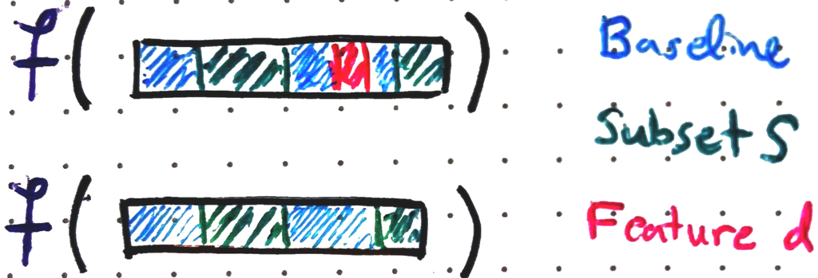

   The figure below represents $C\left(2 \vert 1\right)$ under baseline removal.

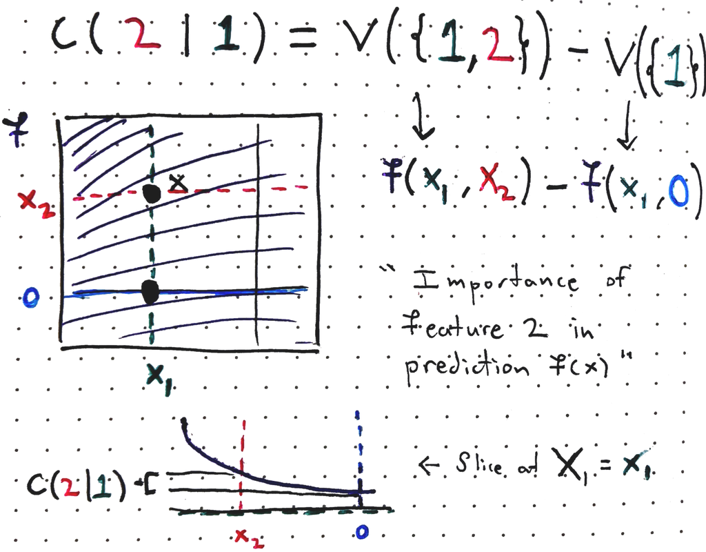

4. The downside of this approach is that it depends on the choice of baseline $x'$, and there is no obvious principled way to choose it.

## Sampling-based Feature Removal

1. Both the marginal and conditional approaches replace the deterministic baseline with an expectation over randomly sampled coordinates. Let $X_{\bar{S}}$ be a random vector of the features *not* in $S$, drawn from the training distribution. The *marginal* approach defines,
   $$v(S) = \Esubarg{p(X_{\bar{S}})}{f(x_{S}, X_{\bar{S}})}
   \tag{2}$$
2. In practice, this expectation can be approximated by the training data, $x_1, \dots, x_{N}$,
   $$v(S) = \frac{1}{N} \sum_{i = 1}^{N} f(x_S, x_{i,\bar{S}}).$$

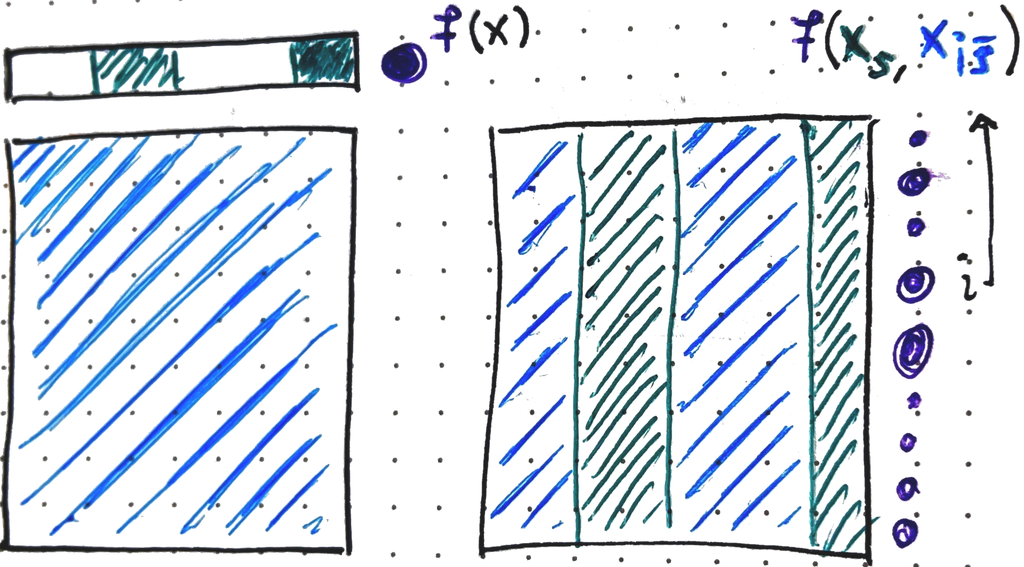

3. To understand this definition geometrically, consider the figure below, which represents $C(2 | 1)$ under marginal removal.
   - **Left panel.** The curved purple lines are contours of $f$ — think of the surface coming out of the page. The large dot at the intersection of the dashed lines is the observation $x = (x_1, x_2)$ whose prediction we want to explain. The smaller dots are training observations $x_i = (x_{i1}, x_{i2})$, and the blue dashed lines connect each $x_i$ to the point $(x_1, x_{i2})$, where the first coordinate has been replaced by $x_1$. These quantities appear directly in $C(2 \mid 1)$:

   $$C(2 \mid 1) = v(\{1,2\}) - v(\{1\}) = f(x) - \mathbb{E}[f(x_1, X_2)] \approx f(x) - \frac{1}{N} \sum_{i} f(x_1, x_{i2})$$
   - **Right panel.** The decreasing curve is a cross-section of $f$ along that vertical dashed line (i.e., holding $x_1$ fixed). The pink dashed line marks $x_2$ for the point we want to explain, and the solid horizontal line has $y$-value equal to $f(x)$. The blue dashed lines show the $x_{i2}$ from training samples, and the blue histogram summarizes the resulting values $f(x_1, x_{i2})$. The gap between $f(x)$ and the center of the histogram is $C(2 \mid 1)$.

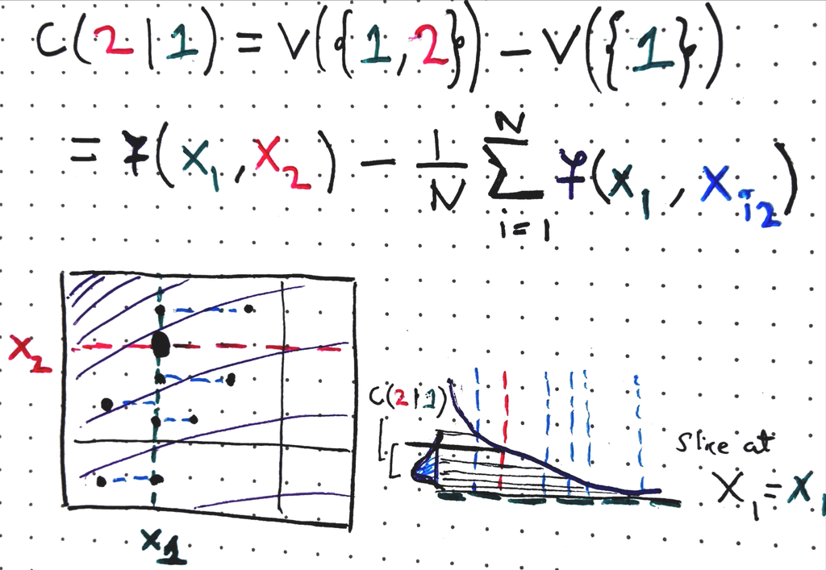

   *Exercise: What would $C\left(1 \vert 2\right)$ look like in this figure? What about $C\left(1 \vert \emptyset\right)$?*

   *Exercise: Would you expect $\varphi_1(f, x)$ to be larger or smaller than $\varphi_2(f, x)$ for the $f$ and $x$ shown? Explain your reasoning.*
4. A potential downside of this approach is that, if features are correlated, the marginal approach may evaluate $f$ at unrealistic input combinations. This is because $X_{\bar{S}}$ is sampled independently from the observed $x_{S}$.

   *Exercise: Modify the previous figure to illustrate this extrapolation issue.*
5. The *conditional* approach addresses this by drawing $X_{\bar{S}}$ from the distribution conditioned on the observed $x_{S}$,

   $$v(S) = \Esubarg{p\left(X_{\bar{S}} \vert X_{S} = x_{S}\right)}{f(x_{S}, X_{\bar{S}})}.$$
6. Unlike the marginal approach, there is no generic estimator for this conditional expectation. Under some assumptions (e.g., multivariate gaussianity), it might be available in closed form. Alternatively, one approach is to train a surrogate model to approximate and sample from the required conditional distributions.

## Causal Intervention Perspective

1. $^\dagger$ Some researchers (Janzing et al. 2020) have argued that point (4) in the previous section is not actually a problem, and that, from a causality perspective, the marginal approach computes the more meaningful expectation.
2. $^\dagger$. To see this, we distinguish between observed data $\tilde{x}$ and model inputs $x$. An intervention conditional distribution sets the input coordinates ${S}$ to $x_{S}$ while leaving $X_{\bar{S}}$ undisturbed, written as
   $$\Earg{f(X_{S}, X_{\bar{S}}) \vert \text{do}(X_{S} = x_{S})}$$
   This differs from ordinary conditioning, which asks “given $X_{S} = x_{S}$, what do we expect $X_{\bar{S}}$ to look like?” In contrast, intervening asks “What if we force $X_S = x_S$ and leave everything else untouched?”

   *Exercise: Compare and contrast interventional conditional distributions with CP profiles.*
3. $^\dagger$ Conditioning on $X_S = x_S$ can change the distribution of $X_{\bar{S}}$ in a way that creates nonzero attributions for any feature $d$ that is correlated with $X_S$, even even if they aren’t in the model. Interventions avoid this because they leave $X_{\bar{S}}$ unchanged.
4. $^\dagger$ To make this concrete, suppose $X_1$ is a thermometer measurement, $X_2$ is the actual temperature, and $f(X_1, X_2) = X_2$ only depends on the actual temperature. Since the two variables are correlated, $\Esubarg{p(X_2 \vert X_1 = x_1)}{X_2} \neq \Earg{X_2}$, so $C(1 \vert \emptyset) \neq 0$ and we get a nonzero attribution for $X_1$, even though it isn’t in the model[^2].
5. $^\dagger$ It turns out that
   $$\Esubarg{p(X_{\bar{S}})}{f(X_{S}, X_{\bar{S}}) \vert \text{do}(X_{S} = x_{S})} = \Esubarg{p(X_{\bar{S}})}{f(x_{S}, X_{\bar{S}})}$$
   The right hand side is exactly the marginal expectation from Equation 2. So, the marginal approach matches a causally meaningful quantity that reflects what it means to remove a feature’s influence.

## Code Example

1. Let’s apply the `shap` python package to identify important variables in the `adult` dataset. Each $x_i$ is a survey response for person $i$, and $y_i$ indicates whether they make more than $50K/year.

   ```python
   import shap
   import matplotlib.pyplot as plt
   plt.rcParams['figure.autolayout'] = True

   X, y = shap.datasets.adult()
   X, y = X.iloc[:2000], y[:2000]   # subsample for speed
   X
   ```

   ```
          Age  Workclass  Education-Num  ...  Capital Loss  Hours per week  Country
   0     39.0          7           13.0  ...           0.0            40.0       39
   1     50.0          6           13.0  ...           0.0            13.0       39
   2     38.0          4            9.0  ...           0.0            40.0       39
   3     53.0          4            7.0  ...           0.0            40.0       39
   4     28.0          4           13.0  ...           0.0            40.0        5
   ...    ...        ...            ...  ...           ...             ...      ...
   1995  44.0          4           10.0  ...           0.0            50.0       39
   1996  49.0          4            9.0  ...           0.0            60.0       39
   1997  75.0          6           14.0  ...           0.0            50.0       39
   1998  37.0          4           13.0  ...           0.0            55.0       39
   1999  51.0          7            9.0  ...           0.0            38.0       39

   [2000 rows x 12 columns]
   ```

2. We train a random forest model to these data using the `sklearn` package.

   ```python
   from sklearn.ensemble import RandomForestClassifier
   model = RandomForestClassifier(n_estimators=100)
   model.fit(X, y)
   ```

   ```
   RandomForestClassifier()
   ```

   ```python
   X_explain = X.iloc[:50]
   predictor = lambda X: model.predict_proba(X)[:, 1]

   #explainer  = shap.KernelExplainer(predictor, X) # if you want to run accurate version
   explainer  = shap.KernelExplainer(predictor, X.sample(100)) # if you want to run the fast version
   sv = explainer.shap_values(X_explain)
   ```

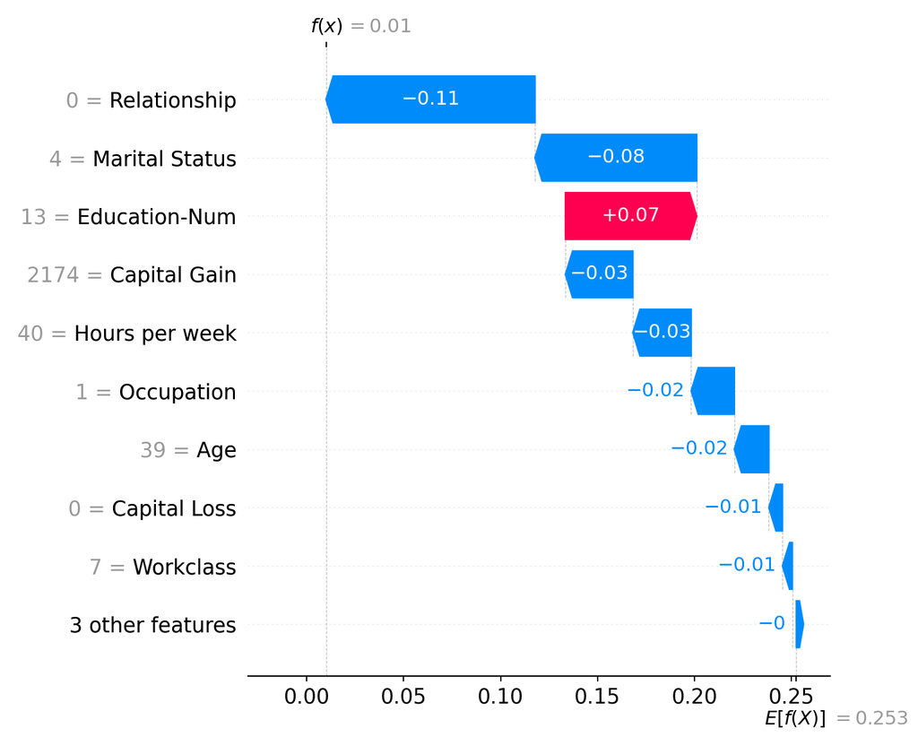

   ```python
   exp_single = shap.Explanation(
    values = sv[0],
    base_values = explainer.expected_value,
    data = X_explain.iloc[0].values,
    feature_names = X_explain.columns.tolist(),
   )
   shap.plots.waterfall(exp_single)
   ```

5. Here is an alternative visualization well-suited for visualizing attributions for multiple samples (lines) simultaneously. This visualization is helpful for identifying clusters of samples with similar feature attributions.

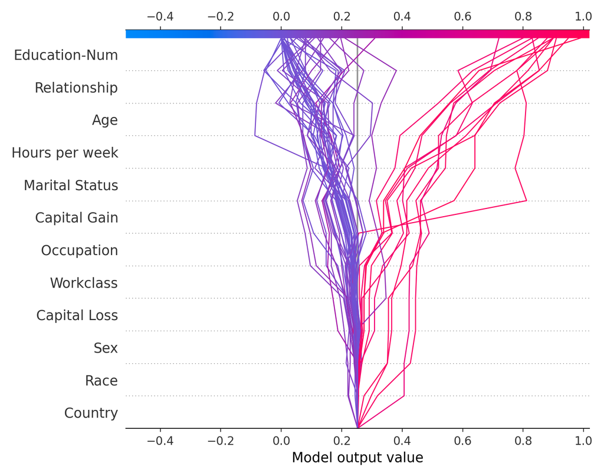

   ```python
   shap.decision_plot(explainer.expected_value, sv, X_explain)
   ```

   *Exercise: Imagine explaining this visualization to a non-data scientist. Describe each component without jargon and summarize the main takeaways within the salary prediction context.*
6. Throughout these notes, we’ve assumed we can easily compute,
   $$\varphi_d(v) = \sum_{S \subseteq \mathcal{D} - \{d\}} \frac{1}{D {D - 1 \choose \left|S\right|}} C(d \vert S)$$
   This is actually challenging to compute! It runs over exponentially many subsets *just to explain a single sample*. So far, we’ve swept this computational challenge under the rug. Next week we’ll discuss practical strategies to computing SHAP values efficiently.

## References

Janzing, Dominik, Lenon Minorics, and Patrick Bloebaum. 2020. *Feature Relevance Quantification in Explainable AI: A Causal Problem*. Proceedings of machine learning research, vol. 108: 2907–16. https://proceedings.mlr.press/v108/janzing20a.html.

Ribeiro, Marco Tulio, Sameer Singh, and Carlos Guestrin. 2016. “‘Why Should i Trust You?’: Explaining the Predictions of Any Classifier.” *Proceedings of the 22nd ACM SIGKDD International Conference on Knowledge Discovery and Data Mining*, KDD ’16, August, 1135–44. https://doi.org/10.1145/2939672.2939778.

## Footnotes

[^1]: That is, if $v_1\left(S \cup \{d\}\right) - v_1(S) \geq v_2\left(S \cup \{d\}\right) - v_2(S)$.
[^2]: In full detail, $C(1 \vert \emptyset) = v(\{1\}) - v(\emptyset) = \Esubarg{p(X_2 \vert X_1 = x_1)}{X_2} - \Esubarg{p(X_1, X_2)}{X_2} \neq 0$ and $C(1 \vert 2) = v(\{1, 2\}) - v(\{2\}) = f(x_1, x_2) - \Esubarg{p(X_1 \vert X_2 = x_2)}{f(X_1, x_2)} = x_2 - x_2 = 0$ where in the last step we used the fact that $f(X_1, x_2) = x_2$ deterministically. Therefore the terms don’t cancel and we obtain a nonzero Shapley value.